# Hello World - pwdgsi, performance metrics, and me

Brian cruice

2021-09-24 09:08:36

## R Markdown

### Working with iris Data

Working in R markdown is a familiar experience, even if my skills are a *bit* rusty. Today we’ll be reviewing some data in the *iris* data set including in R, primarily through the use of the *dplyr* and *ggplot* packages, which are a part of the larger *tidyverse* set of packages. Below are a few simple plots of the data without any manipulation. Below we have the simplest form of boxplot output for ggplot.

|  | Sepal.Length | Sepal.Width | Petal.Length | Petal.Width | Species |
| --- | --- | --- | --- | --- | --- |
| 1 | 5.1 | 3.5 | 1.4 | 0.2 | setosa |
| 2 | 4.9 | 3 | 1.4 | 0.2 | setosa |
| 3 | 4.7 | 3.2 | 1.3 | 0.2 | setosa |
| 4 | 4.6 | 3.1 | 1.5 | 0.2 | setosa |
| 5 | 5 | 3.6 | 1.4 | 0.2 | setosa |
| 6 | 5.4 | 3.9 | 1.7 | 0.4 | setosa |
| 7 | 4.6 | 3.4 | 1.4 | 0.3 | setosa |
| 8 | 5 | 3.4 | 1.5 | 0.2 | setosa |
| 9 | 4.4 | 2.9 | 1.4 | 0.2 | setosa |
| 10 | 4.9 | 3.1 | 1.5 | 0.1 | setosa |

[output cut: 140 more lines]

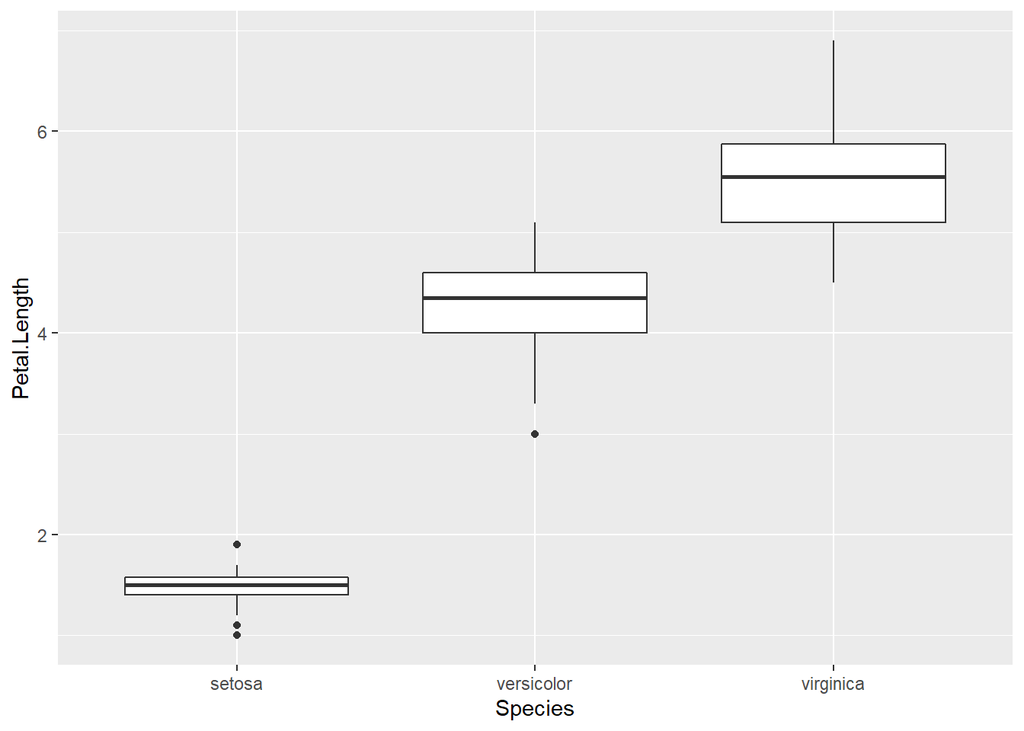

Isn’t it awful? Why are the whiskers tied to individual data points? Why can’t we see those data points? Doesn’t the rest of the box represent descriptive statistics of the dataset? Can’t we just see all of the data as well as a representation of the spread in one graph? Also, we need to make the labels clearer and make the whole thing pop. Let’s clean it up. We’ll need to know some ggplot, some dplyr, and some base stat functions to get there.

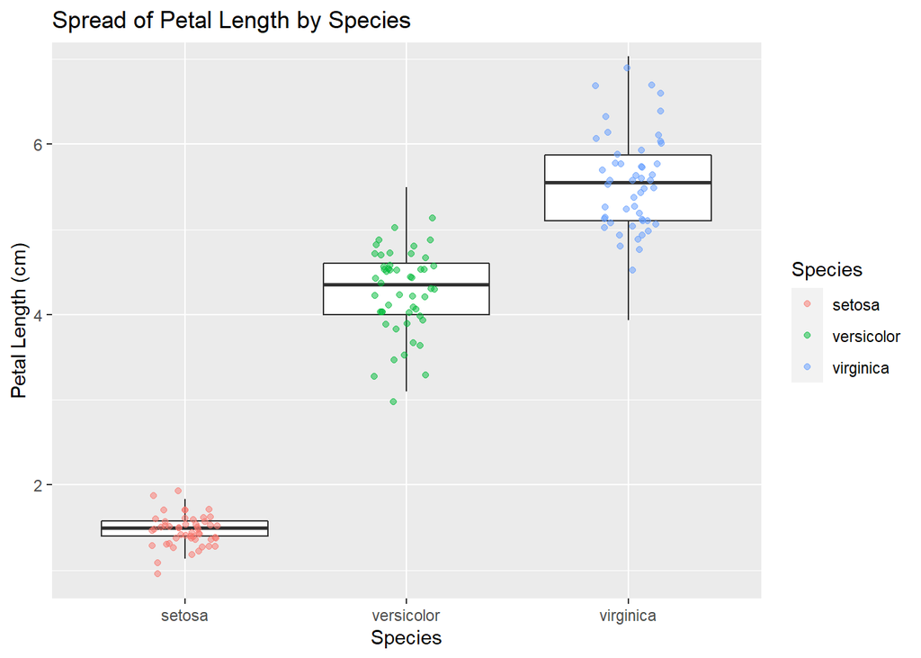

```r
petal.stats <- quantile(iris$Petal.Length)
#set lower whisker to lower hinge - 1.5*IQR
petal.whisk.min <- petal.stats[2] - 1.5*(petal.stats[4]-petal.stats[2])
#set upper whisker to upper hinge + 1.5*IQR
petal.whisk.max <- petal.stats[4] + 1.5*(petal.stats[4]-petal.stats[2])

petal.stats <- iris %>% group_by(Species) %>%
               summarize("low.whisk" = quantile(Petal.Length)[2] - 1.5*(quantile(Petal.Length)[4]-quantile(Petal.Length)[2]),
                         "up.whisk" = quantile(Petal.Length)[4] + 1.5*(quantile(Petal.Length)[4]-quantile(Petal.Length)[2]))

iris.box.better <- ggplot(iris, aes(x = Species, y = Petal.Length)) + geom_boxplot(outlier.shape =NA,
                                                                                   ymin = petal.stats$low.whisk,
                                                                                   ymax = petal.stats$up.whisk) +
                   geom_jitter(width= 0.15, alpha = 0.5, aes(col = Species)) +
                   xlab("Species") + ylab("Petal Length (cm)") + ggtitle("Spread of Petal Length by Species")
iris.box.better
```

Isn’t that just better? Now lets make a table summarizing some of what we see here. Once we’re done reviewing, we can move on to the MARS data.

|  | Species | Mean Length (cm) | Median Length (cm) | Lower Quartile (cm) | Upper Quartile (cm) | Minimum Length (cm) | Maximum Length (cm) |
| --- | --- | --- | --- | --- | --- | --- | --- |
| 1 | setosa | 1.462 | 1.5 | 1.4 | 1.575 | 1 | 1.9 |
| 2 | versicolor | 4.26 | 4.35 | 4 | 4.6 | 3 | 5.1 |
| 3 | virginica | 5.552 | 5.55 | 5.1 | 5.875 | 4.5 | 6.9 |

### Working with MARS Data

Working with pwdgsi, we are able to grab data from several tables within the **mars_testing** database and save them as lists or database objects in R.

#### Running pwdgsi Functions

Below is the beginning of the level data for 250-1-1 during the period of 01/01/2019 to 09/01/2021. This is one of three dataframes created by queries to the **mars_testing** database performed by the function **marsFetchMonitoringData**.

```
##             dtime_est level_ft ow_uid radar_uid radar_event_uid
## 1 2019-01-17 11:15:00        0    779    105963              NA
## 2 2019-01-17 11:30:00        0    779    105963              NA
## 3 2019-01-17 11:45:00        0    779    105963              NA
## 4 2019-01-17 12:00:00        0    779    105963              NA
## 5 2019-01-17 12:15:00        0    779    105963              NA
## 6 2019-01-17 12:30:00        0    779    105963              NA
```

#### Replicating pwdgsi Functions

The functions in **pwdgsi** are there to streamline common queries to the MARS database. However, to better understand the code behind the functions and their intended purposes, I’m showing how I would recreate the list object outputted by **marsFetchMonitoringData** using the functions in the R packages **odbc** and **DBI**.

```r
#Save a vector of tables to find the appropriate ones to query.
mars_tables <- dbListTables(mars)

#Initiate a null list to populate with dataframes from queries.
smp250_1_1 <- list()


#Query targetId
targetId <- dbGetQuery(mars,
                       paste0("SELECT ow_uid FROM fieldwork.ow WHERE smp_id = '",
                              smpId,
                               "' AND ow_suffix = '",
                              owId, "'")
                      )


#Query level data
level_data <- dbGetQuery(mars,
                        paste0(
                          "SELECT o.dtime_est, o.level_ft, o.ow_uid
                            FROM data.ow_leveldata_raw o
                            WHERE o.ow_uid = ", targetId)
)

smp250_1_1$`Level Data` <- level_data %>%
                            dplyr::filter(dtime_est >= start_date) %>%
                           dplyr::filter(dtime_est <= end_date)
head(smp250_1_1$`Level Data`)
```

```
##             dtime_est level_ft ow_uid
## 1 2019-01-17 11:15:00  -0.0881    779
## 2 2019-01-17 11:30:00  -0.0542    779
## 3 2019-01-17 11:45:00  -0.0549    779
## 4 2019-01-17 12:00:00  -0.0501    779
## 5 2019-01-17 12:15:00  -0.0561    779
## 6 2019-01-17 12:30:00  -0.0551    779
```

This is close to the level data grabbed by **marsFetchMonitoringData**, but it still needs to be joined to rain gauge data and rainfall events and processed to no longer be “raw” data. I also suspect that filtering for time after the query whether than building it into the query is a more process intensive way of reaching this result.

#### SMP 250-1-1☺

Rather than continuing to replicate an existing function, let’s inspect the data for 250-1-1. Let’s create some summary statistics for these data.

##### Summary Statistics

The total number of rain events between 2019-01-01 and 2021-09-01 is 154.

The mean duration of these 154 events was 10.2 hours with a mean peak intensity of 0.53 in/hr and a mean depth of 0.66 inches.

#### View Key Metrics

We’ve now run some code (courtesy of Nick Manna) that let’s us look at the key metrics for each storm event within the period. The table below includes all events within the timeframe. As you can see, 55.2% of all events received the -900 error for infiltration rate, with the mean depth of these events being 0.2846706 inches. This means the event does not include observation data that approximately equals specified water depth. These events will not be useful for testing system functionality. Instead we should try filtering the table to display the largest storms first.

|  | radar_event_uid | ow_uid | percentstorageused_peak | percentstorageused_relative | baseline | infiltration_inhr | draindown_hr | draindownAssessment | overtop | peakReleaseRate_cfs | orifice_volume_cf | snapshot_uid | observed_simulated_lookup_uid |
| --- | --- | --- | --- | --- | --- | --- | --- | --- | --- | --- | --- | --- | --- |
| 1 | 188406 | 779 | 41.6475 | 41.6475 | 0 | -920 | 21 | 5 | FALSE | 0.0063 | 143 | 317 | 1 |
| 2 | 188407 | 779 | 48.0275 | 48.0275 | 0 | 1.562 | 20.5 | 5 | FALSE | 0.0072 | 153 | 317 | 1 |
| 3 | 188408 | 779 | 0 | 0 | 0 | -900 | -810 | 1 | FALSE |  | 0 | 317 | 1 |
| 4 | 188409 | 779 | 2.42 | 2.42 | 0 | -900 | -810 | 1 | FALSE |  | 0 | 317 | 1 |
| 5 | 188410 | 779 | 0 | 0 | 0 | -900 | -810 | 1 | FALSE |  | 0 | 317 | 1 |
| 6 | 188411 | 779 | 27.835 | 27.835 | 0 | -920 | 22.25 | 5 | FALSE | 0.0038 | 75 | 317 | 1 |
| 7 | 188412 | 779 | 6.9075 | 6.9075 | 0 | -900 | 8.75 | 5 | FALSE |  | 0 | 317 | 1 |
| 8 | 188413 | 779 | 14.6575 | 14.6575 | 0 | 0.753 | 25.75 | 3 | FALSE |  | 0 | 317 | 1 |
| 9 | 188414 | 779 | 16.6475 | 16.6475 | 0 | -920 | 18.5 | 5 | FALSE |  | 0 | 317 | 1 |
| 10 | 188415 | 779 | 0 | 0 | 0 | -900 | -810 | 1 | FALSE |  | 0 | 317 | 1 |

[output cut: 144 more lines]

#### Plotting MARS Data

Below are the plots for draw down for 250-1-1 during the two largest events, by total precipitation depth, measured between the dates 01/01/19 and 09/01/21.

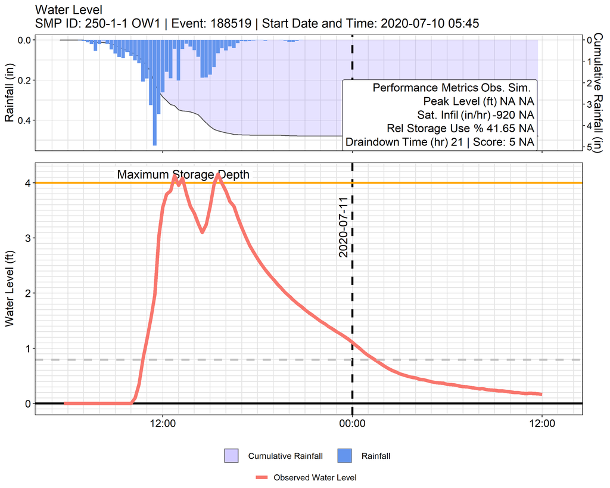

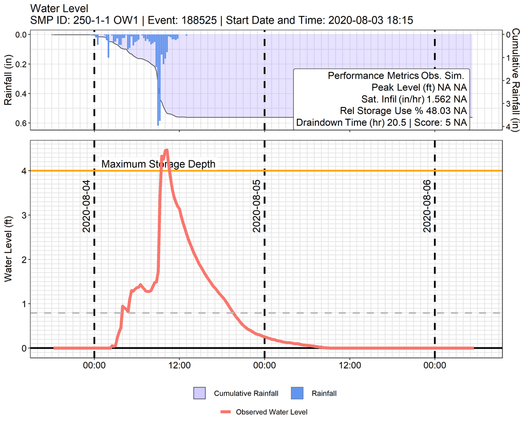